# Исследование объявлений о продаже квартир

##### Заполним пропущенные значения

Посмотрим сколько пропущенных значений в каждом столбце в процентом соотношении:

```python
data.isna().sum().sort_values(ascending=False)/data.shape[0]*100
```

```
is_apartment            88.290645
parks_nearest           65.909954
ponds_nearest           61.559559
balcony                 48.605426
ceiling_height          38.799105
airports_nearest        23.384953
cityCenters_nearest     23.287902
ponds_around3000        23.283683
parks_around3000        23.283683
days_exposition         13.422507
kitchen_area             9.612220
living_area              8.029875
floors_total             0.362885
locality_name            0.206760
total_images             0.000000
last_price               0.000000
studio                   0.000000
floor                    0.000000
rooms                    0.000000
first_day_exposition     0.000000
total_area               0.000000
open_plan                0.000000
dtype: float64
```

**Вывод**: в столбце locality_name процент пропусков всего 0,2%. Удалим эти строки, т.к. у данных объектов нет информации по местоположению и они будут мешать в анализе. Также поступим с пропущенными данным в столбце floors_total.

```python
data = data.dropna(subset=['locality_name', 'floors_total']) #удалим пропуски
data.isna().sum().sort_values(ascending=False) #проверим себя
```

```
is_apartment            20805
parks_nearest           15535
ponds_nearest           14529
balcony                 11475
ceiling_height           9084
airports_nearest         5524
cityCenters_nearest      5501
ponds_around3000         5500
parks_around3000         5500
days_exposition          3171
kitchen_area             2222
living_area              1865
locality_name               0
total_images                0
last_price                  0
studio                      0
floor                       0
floors_total                0
rooms                       0
first_day_exposition        0
total_area                  0
open_plan                   0
dtype: int64
```

Произведем замену пропусков нужно в столбцах balcony, parks_around3000, ponds_around3000.

```python
data['balcony'] = data['balcony'].fillna(0)
data['parks_around3000'] = data['parks_around3000'].fillna('0')
data['ponds_around3000'] = data['ponds_around3000'].fillna('0')
data.isna().sum().sort_values(ascending=False)#проверим себя
```

```
is_apartment            20805
parks_nearest           15535
ponds_nearest           14529
ceiling_height           9084
airports_nearest         5524
cityCenters_nearest      5501
days_exposition          3171
kitchen_area             2222
living_area              1865
balcony                     0
ponds_around3000            0
parks_around3000            0
locality_name               0
total_images                0
last_price                  0
studio                      0
floor                       0
floors_total                0
rooms                       0
first_day_exposition        0
total_area                  0
open_plan                   0
dtype: int64
```

Больше всего пропусков содержится в столбце is_apartment. Вероятнее всего пропуск в данном столбце означает, что объект не относится к апартоментам.

```python
data['is_apartment'] = data['is_apartment'].fillna(value=False)#заменим пропуск на False
data.isna().sum().sort_values(ascending=False)#проверим себя
```

```
parks_nearest           15535
ponds_nearest           14529
ceiling_height           9084
airports_nearest         5524
cityCenters_nearest      5501
days_exposition          3171
kitchen_area             2222
living_area              1865
ponds_around3000            0
parks_around3000            0
locality_name               0
balcony                     0
total_images                0
last_price                  0
studio                      0
is_apartment                0
floor                       0
floors_total                0
rooms                       0
first_day_exposition        0
total_area                  0
open_plan                   0
dtype: int64
```

Также много пропусков в столбце ceiling_height. Заменим на медианное значение по всему датасету. Для этого сначала распечатаем медиану и посмотрим корректное ли это значение.

```python
print(data['ceiling_height'].median())
```

```
2.65
```

Значение отражает реальность, поэтому произведем замену.

```python
data['ceiling_height'] = data['ceiling_height'].fillna(data['ceiling_height'].median())
data.info()
```

```
<class 'pandas.core.frame.DataFrame'>
Int64Index: 23565 entries, 0 to 23698
Data columns (total 22 columns):
 #   Column                Non-Null Count  Dtype
---  ------                --------------  -----
 0   total_images          23565 non-null  int64
 1   last_price            23565 non-null  float64
 2   total_area            23565 non-null  float64
 3   first_day_exposition  23565 non-null  object
 4   rooms                 23565 non-null  int64
 5   ceiling_height        23565 non-null  float64
 6   floors_total          23565 non-null  float64
 7   living_area           21700 non-null  float64
 8   floor                 23565 non-null  int64
 9   is_apartment          23565 non-null  bool
 10  studio                23565 non-null  bool
 11  open_plan             23565 non-null  bool
 12  kitchen_area          21343 non-null  float64
 13  balcony               23565 non-null  float64
 14  locality_name         23565 non-null  object
 15  airports_nearest      18041 non-null  float64
 16  cityCenters_nearest   18064 non-null  float64
 17  parks_around3000      23565 non-null  object
 18  parks_nearest         8030 non-null   float64
 19  ponds_around3000      23565 non-null  object
 20  ponds_nearest         9036 non-null   float64
 21  days_exposition       20394 non-null  float64
dtypes: bool(3), float64(12), int64(3), object(4)
memory usage: 3.7+ MB
```

```python
data.head(10)
```

|  | total_images | last_price | total_area | first_day_exposition | rooms | ceiling_height | floors_total | living_area | floor | is_apartment | studio | open_plan | kitchen_area | balcony | locality_name | airports_nearest | cityCenters_nearest | parks_around3000 | parks_nearest | ponds_around3000 | ponds_nearest | days_exposition |
| --- | --- | --- | --- | --- | --- | --- | --- | --- | --- | --- | --- | --- | --- | --- | --- | --- | --- | --- | --- | --- | --- | --- |
| 0 | 20 | 13000000.0 | 108.00 | 2019-03-07T00:00:00 | 3 | 2.70 | 16.0 | 51.00 | 8 | False | False | False | 25.00 | 0.0 | Санкт-Петербург | 18863.0 | 16028.0 | 1.0 | 482.0 | 2.0 | 755.0 | NaN |
| 1 | 7 | 3350000.0 | 40.40 | 2018-12-04T00:00:00 | 1 | 2.65 | 11.0 | 18.60 | 1 | False | False | False | 11.00 | 2.0 | посёлок Шушары | 12817.0 | 18603.0 | 0.0 | NaN | 0.0 | NaN | 81.0 |
| 2 | 10 | 5196000.0 | 56.00 | 2015-08-20T00:00:00 | 2 | 2.65 | 5.0 | 34.30 | 4 | False | False | False | 8.30 | 0.0 | Санкт-Петербург | 21741.0 | 13933.0 | 1.0 | 90.0 | 2.0 | 574.0 | 558.0 |
| 3 | 0 | 64900000.0 | 159.00 | 2015-07-24T00:00:00 | 3 | 2.65 | 14.0 | NaN | 9 | False | False | False | NaN | 0.0 | Санкт-Петербург | 28098.0 | 6800.0 | 2.0 | 84.0 | 3.0 | 234.0 | 424.0 |
| 4 | 2 | 10000000.0 | 100.00 | 2018-06-19T00:00:00 | 2 | 3.03 | 14.0 | 32.00 | 13 | False | False | False | 41.00 | 0.0 | Санкт-Петербург | 31856.0 | 8098.0 | 2.0 | 112.0 | 1.0 | 48.0 | 121.0 |
| 5 | 10 | 2890000.0 | 30.40 | 2018-09-10T00:00:00 | 1 | 2.65 | 12.0 | 14.40 | 5 | False | False | False | 9.10 | 0.0 | городской посёлок Янино-1 | NaN | NaN | 0 | NaN | 0 | NaN | 55.0 |
| 6 | 6 | 3700000.0 | 37.30 | 2017-11-02T00:00:00 | 1 | 2.65 | 26.0 | 10.60 | 6 | False | False | False | 14.40 | 1.0 | посёлок Парголово | 52996.0 | 19143.0 | 0.0 | NaN | 0.0 | NaN | 155.0 |
| 7 | 5 | 7915000.0 | 71.60 | 2019-04-18T00:00:00 | 2 | 2.65 | 24.0 | NaN | 22 | False | False | False | 18.90 | 2.0 | Санкт-Петербург | 23982.0 | 11634.0 | 0.0 | NaN | 0.0 | NaN | NaN |
| 8 | 20 | 2900000.0 | 33.16 | 2018-05-23T00:00:00 | 1 | 2.65 | 27.0 | 15.43 | 26 | False | False | False | 8.81 | 0.0 | посёлок Мурино | NaN | NaN | 0 | NaN | 0 | NaN | 189.0 |
| 9 | 18 | 5400000.0 | 61.00 | 2017-02-26T00:00:00 | 3 | 2.50 | 9.0 | 43.60 | 7 | False | False | False | 6.50 | 2.0 | Санкт-Петербург | 50898.0 | 15008.0 | 0.0 | NaN | 0.0 | NaN | 289.0 |

##### Причины, которые могли привести к пропускам в данных.

**Вывод:**  
Пропуски данных по большей части обусловлены неполноценным заполнением всех полей в форме объявления. Если данная информация принципиальна, то, возможно, стоит сделать эти поля обязательными для заполнения.

#### Рассмотрим типы данных в каждом столбце.

##### Найдем столбцы, в которых нужно изменить тип данных

Повторно вызовем всю информацию по таблице.

```python
data.info()
```

```
<class 'pandas.core.frame.DataFrame'>
Int64Index: 23565 entries, 0 to 23698
Data columns (total 22 columns):
 #   Column                Non-Null Count  Dtype
---  ------                --------------  -----
 0   total_images          23565 non-null  int64
 1   last_price            23565 non-null  float64
 2   total_area            23565 non-null  float64
 3   first_day_exposition  23565 non-null  object
 4   rooms                 23565 non-null  int64
 5   ceiling_height        23565 non-null  float64
 6   floors_total          23565 non-null  float64
 7   living_area           21700 non-null  float64
 8   floor                 23565 non-null  int64
 9   is_apartment          23565 non-null  bool
 10  studio                23565 non-null  bool
 11  open_plan             23565 non-null  bool
 12  kitchen_area          21343 non-null  float64
 13  balcony               23565 non-null  float64
 14  locality_name         23565 non-null  object
 15  airports_nearest      18041 non-null  float64
 16  cityCenters_nearest   18064 non-null  float64
 17  parks_around3000      23565 non-null  object
 18  parks_nearest         8030 non-null   float64
 19  ponds_around3000      23565 non-null  object
 20  ponds_nearest         9036 non-null   float64
 21  days_exposition       20394 non-null  float64
dtypes: bool(3), float64(12), int64(3), object(4)
memory usage: 3.7+ MB
```

##### Преобразуем тип данных в выбранных столбцах.

```python
data.astype({ 'balcony': 'int', 'parks_around3000': 'int', 'floors_total': 'int'})
data['is_apartment'] = data['is_apartment'].astype('bool')#изменин на булевый тип
data['first_day_exposition'] = pd.to_datetime(data['first_day_exposition'], format='%Y.%m.%d %H:%M:%S')
data.info()
```

```
<class 'pandas.core.frame.DataFrame'>
Int64Index: 23565 entries, 0 to 23698
Data columns (total 22 columns):
 #   Column                Non-Null Count  Dtype
---  ------                --------------  -----
 0   total_images          23565 non-null  int64
 1   last_price            23565 non-null  float64
 2   total_area            23565 non-null  float64
 3   first_day_exposition  23565 non-null  datetime64[ns]
 4   rooms                 23565 non-null  int64
 5   ceiling_height        23565 non-null  float64
 6   floors_total          23565 non-null  float64
 7   living_area           21700 non-null  float64
 8   floor                 23565 non-null  int64
 9   is_apartment          23565 non-null  bool
 10  studio                23565 non-null  bool
 11  open_plan             23565 non-null  bool
 12  kitchen_area          21343 non-null  float64
 13  balcony               23565 non-null  float64
 14  locality_name         23565 non-null  object
 15  airports_nearest      18041 non-null  float64
 16  cityCenters_nearest   18064 non-null  float64
 17  parks_around3000      23565 non-null  object
 18  parks_nearest         8030 non-null   float64
 19  ponds_around3000      23565 non-null  object
 20  ponds_nearest         9036 non-null   float64
 21  days_exposition       20394 non-null  float64
dtypes: bool(3), datetime64[ns](1), float64(12), int64(3), object(3)
memory usage: 3.7+ MB
```

##### Почему нужно изменить тип данных.

**Вывод:** Для того, чтобы провести качественный анализ, нужно проводить различные манипуляции с данными. Без изменения типа данных можно в определенный момент столкнуться с ошибками.

#### Изучим уникальные значения в столбце с названиями и устраните неявные дубликаты.

Выведем перечень уникальных значений столбца locality_name, отсротированный по алфавиту.

```python
data['locality_name'].sort_values().unique()
```

```
array(['Бокситогорск', 'Волосово', 'Волхов', 'Всеволожск', 'Выборг',
       'Высоцк', 'Гатчина', 'Зеленогорск', 'Ивангород', 'Каменногорск',
       'Кингисепп', 'Кириши', 'Кировск', 'Колпино', 'Коммунар',
       'Красное Село', 'Кронштадт', 'Кудрово', 'Лодейное Поле',
       'Ломоносов', 'Луга', 'Любань', 'Мурино', 'Никольское',
       'Новая Ладога', 'Отрадное', 'Павловск', 'Петергоф', 'Пикалёво',
       'Подпорожье', 'Приморск', 'Приозерск', 'Пушкин', 'Санкт-Петербург',
       'Светогорск', 'Сертолово', 'Сестрорецк', 'Сланцы', 'Сосновый Бор',
       'Сясьстрой', 'Тихвин', 'Тосно', 'Шлиссельбург',
       'городской поселок Большая Ижора', 'городской поселок Янино-1',
       'городской посёлок Будогощь', 'городской посёлок Виллози',
       'городской посёлок Лесогорский', 'городской посёлок Мга',
       'городской посёлок Назия', 'городской посёлок Новоселье',
       'городской посёлок Павлово', 'городской посёлок Рощино',
       'городской посёлок Свирьстрой', 'городской посёлок Советский',
       'городской посёлок Фёдоровское', 'городской посёлок Янино-1',
       'деревня Агалатово', 'деревня Аро', 'деревня Батово',
       'деревня Бегуницы', 'деревня Белогорка', 'деревня Большая Вруда',
       'деревня Большая Пустомержа', 'деревня Большие Колпаны',
       'деревня Большое Рейзино', 'деревня Большой Сабск', 'деревня Бор',
       'деревня Борисова Грива', 'деревня Ваганово', 'деревня Вартемяги',
       'деревня Вахнова Кара', 'деревня Выскатка', 'деревня Гарболово',
       'деревня Глинка', 'деревня Горбунки', 'деревня Гостилицы',
       'деревня Заклинье', 'деревня Заневка', 'деревня Зимитицы',
       'деревня Извара', 'деревня Иссад', 'деревня Калитино',
       'деревня Кальтино', 'деревня Камышовка', 'деревня Каськово',
       'деревня Келози', 'деревня Кипень', 'деревня Кисельня',
       'деревня Колтуши', 'деревня Коркино', 'деревня Котлы',
       'деревня Кривко', 'деревня Кудрово', 'деревня Кузьмолово',
       'деревня Курковицы', 'деревня Куровицы', 'деревня Куттузи',
       'деревня Лаврики', 'деревня Лаголово', 'деревня Лампово',
       'деревня Лесколово', 'деревня Лопухинка', 'деревня Лупполово',
       'деревня Малая Романовка', 'деревня Малое Верево',
       'деревня Малое Карлино', 'деревня Малые Колпаны',
       'деревня Мануйлово', 'деревня Меньково', 'деревня Мины',
       'деревня Мистолово', 'деревня Ненимяки', 'деревня Нижние Осельки',
       'деревня Нижняя', 'деревня Низино', 'деревня Новое Девяткино',
       'деревня Новолисино', 'деревня Нурма', 'деревня Оржицы',
       'деревня Парицы', 'деревня Пельгора', 'деревня Пеники',
       'деревня Пижма', 'деревня Пикколово', 'деревня Пудомяги',
```

[output cut: 96 more lines]

```
       'посёлок городского типа Тайцы', 'посёлок городского типа Токсово',
       'посёлок городского типа Ульяновка',
       'посёлок городского типа Форносово',
       'посёлок городского типа имени Морозова',
       'посёлок городского типа имени Свердлова',
       'посёлок при железнодорожной станции Вещево',
       'посёлок при железнодорожной станции Приветнинское',
       'посёлок станции Громово', 'посёлок станции Свирь',
       'садоводческое некоммерческое товарищество Лесная Поляна',
       'садовое товарищество Новая Ропша',
       'садовое товарищество Приладожский', 'садовое товарищество Рахья',
       'садовое товарищество Садко', 'село Копорье', 'село Никольское',
       'село Павлово', 'село Паша', 'село Путилово', 'село Рождествено',
       'село Русско-Высоцкое', 'село Старая Ладога', 'село Шум'],
      dtype=object)
```

Посчитаем сколько уникальных значений сейчас:

```python
len(data['locality_name'].sort_values().unique())
```

```
364
```

```python
#Чаще всего встречается неявные дубликаты с буквами е и ё. Избавимся от этого.
data['locality_name'] = data['locality_name'].str.replace('ё', 'е', regex=True)
data['locality_name'].sort_values().unique()
```

```
array(['Бокситогорск', 'Волосово', 'Волхов', 'Всеволожск', 'Выборг',
       'Высоцк', 'Гатчина', 'Зеленогорск', 'Ивангород', 'Каменногорск',
       'Кингисепп', 'Кириши', 'Кировск', 'Колпино', 'Коммунар',
       'Красное Село', 'Кронштадт', 'Кудрово', 'Лодейное Поле',
       'Ломоносов', 'Луга', 'Любань', 'Мурино', 'Никольское',
       'Новая Ладога', 'Отрадное', 'Павловск', 'Петергоф', 'Пикалево',
       'Подпорожье', 'Приморск', 'Приозерск', 'Пушкин', 'Санкт-Петербург',
       'Светогорск', 'Сертолово', 'Сестрорецк', 'Сланцы', 'Сосновый Бор',
       'Сясьстрой', 'Тихвин', 'Тосно', 'Шлиссельбург',
       'городской поселок Большая Ижора', 'городской поселок Будогощь',
       'городской поселок Виллози', 'городской поселок Лесогорский',
       'городской поселок Мга', 'городской поселок Назия',
       'городской поселок Новоселье', 'городской поселок Павлово',
       'городской поселок Рощино', 'городской поселок Свирьстрой',
       'городской поселок Советский', 'городской поселок Федоровское',
       'городской поселок Янино-1', 'деревня Агалатово', 'деревня Аро',
       'деревня Батово', 'деревня Бегуницы', 'деревня Белогорка',
       'деревня Большая Вруда', 'деревня Большая Пустомержа',
       'деревня Большие Колпаны', 'деревня Большое Рейзино',
       'деревня Большой Сабск', 'деревня Бор', 'деревня Борисова Грива',
       'деревня Ваганово', 'деревня Вартемяги', 'деревня Вахнова Кара',
       'деревня Выскатка', 'деревня Гарболово', 'деревня Глинка',
       'деревня Горбунки', 'деревня Гостилицы', 'деревня Заклинье',
       'деревня Заневка', 'деревня Зимитицы', 'деревня Извара',
       'деревня Иссад', 'деревня Калитино', 'деревня Кальтино',
       'деревня Камышовка', 'деревня Каськово', 'деревня Келози',
       'деревня Кипень', 'деревня Кисельня', 'деревня Колтуши',
       'деревня Коркино', 'деревня Котлы', 'деревня Кривко',
       'деревня Кудрово', 'деревня Кузьмолово', 'деревня Курковицы',
       'деревня Куровицы', 'деревня Куттузи', 'деревня Лаврики',
       'деревня Лаголово', 'деревня Лампово', 'деревня Лесколово',
       'деревня Лопухинка', 'деревня Лупполово',
       'деревня Малая Романовка', 'деревня Малое Верево',
       'деревня Малое Карлино', 'деревня Малые Колпаны',
       'деревня Мануйлово', 'деревня Меньково', 'деревня Мины',
       'деревня Мистолово', 'деревня Ненимяки', 'деревня Нижние Осельки',
       'деревня Нижняя', 'деревня Низино', 'деревня Новое Девяткино',
       'деревня Новолисино', 'деревня Нурма', 'деревня Оржицы',
       'деревня Парицы', 'деревня Пельгора', 'деревня Пеники',
       'деревня Пижма', 'деревня Пикколово', 'деревня Пудомяги',
```

[output cut: 79 more lines]

```
       'поселок городского типа Форносово',
       'поселок городского типа имени Морозова',
       'поселок городского типа имени Свердлова',
       'поселок при железнодорожной станции Вещево',
       'поселок при железнодорожной станции Приветнинское',
       'поселок станции Вещево', 'поселок станции Громово',
       'поселок станции Корнево', 'поселок станции Лужайка',
       'поселок станции Приветнинское', 'поселок станции Свирь',
       'садоводческое некоммерческое товарищество Лесная Поляна',
       'садовое товарищество Новая Ропша',
       'садовое товарищество Приладожский', 'садовое товарищество Рахья',
       'садовое товарищество Садко', 'село Копорье', 'село Никольское',
       'село Павлово', 'село Паша', 'село Путилово', 'село Рождествено',
       'село Русско-Высоцкое', 'село Старая Ладога', 'село Шум'],
      dtype=object)
```

```python
# Столько уникальных значений сейчас
len(data['locality_name'].sort_values().unique())
```

```
330
```

Итог: избавились от 34 неявных дубликатов.

```python
#Встречается поселок Рябово и поселок городского типа Рябово. Скорее всего это один и тот же населенный пункт. Избавимся от него.
data = data.loc[data['locality_name'] != 'поселок Рябово']
len(data['locality_name'].sort_values().unique())
```

```
329
```

Избавились от еще одного неявного дубликата. Могут встречаться и другие повторы в названиях, но так как нет достоверной информации о том, что это действительно один и тот же населеный пункт, то не будем вносить изменения.

#### Найдем и устраним редкие и выбивающиеся значения.

Изучим столбцы data данными, вводимыми пользователями, напредмет редких и выбивающихся значений.

##### Столбец total_images

```python
data['total_images'].unique()
```

```
array([20,  7, 10,  0,  2,  6,  5, 18,  9,  1, 16, 11,  8, 12, 13,  3, 15,
       17, 14, 19, 32,  4, 35, 39, 23, 21, 27, 30, 24, 25, 28, 31, 22, 29,
       26, 50, 42, 37])
```

**Вывод:** необычных значений не вижу. В тех. задании нет упоминания о том, какое количество изображений может быть добавленно максимально, поэтому количество 50 не принимаю за выбивающееся.

##### Столбец last_price

```python
print(data['last_price'].unique())
print('минимальная цена: ', data['last_price'].min())
print('максимальная цена: ', data['last_price'].max())
```

```
[13000000.  3350000.  5196000. ...  6151120. 21400000. 11475000.]
минимальная цена:  12190.0
максимальная цена:  763000000.0
```

Видим, что минимальная цена в квартиру выставлена 12190, что не представляется реальным. Удалим строки с данным значением.

```python
data = data.loc[data['last_price'] != 12190]
print('минимальная цена: ', data['last_price'].min())
```

```
минимальная цена:  430000.0
```

Теперь минимальная цена составляет 430 000 рублей. Что больше похоже на реальность - в небольшом населенном пункте недвижимость вполне может столько стоить. Максимальная же цена 763 000 000 рублей, что много, но тоже реально.

##### Столбец total_area

```python
print(data['total_area'].unique())
print('минимальная общая площадь: ', data['total_area'].min())
print('максимальная общая площадь: ', data['total_area'].max())
```

```
[108.    40.4   56.   ...  66.86 133.81  76.75]
минимальная общая площадь:  12.0
максимальная общая площадь:  900.0
```

**Вывод:** если говорить о студии, то площадь в 12 кв.м. представляется реальной. Также и квартира может быть 900 кв.м. Значения не считаю выбивающимися.

##### Столбец rooms

```python
print(data['rooms'].unique())
print('минимальное кол. комнат: ', data['rooms'].min())
print('максимальное кол. комнат: ', data['rooms'].max())
```

```
[ 3  1  2  4  5  6  0  7 11  8 14 10 15  9 19 16 12]
минимальное кол. комнат:  0
максимальное кол. комнат:  19
```

```python
#нулевое количество комнат быть не может. Избавимся от некоректных значений
data = data.loc[data['rooms'] != 0]
print('минимальное кол. комнат: ', data['rooms'].min())
```

```
минимальное кол. комнат:  1
```

**Вывод:** избавились от некорректного значения 0 комнат. Минимальное стало 1. Максимальное 19 комант, что тоже может быть возможным.

##### Столбец ceiling_height

```python
print(data['ceiling_height'].unique())
len(data['ceiling_height'].unique())
```

```
[  2.7    2.65   3.03   2.5    2.67   2.56   3.05   2.75   2.6    2.9
   2.8    2.55   3.     3.2    2.61   3.25   3.45   2.77   2.85   2.64
   2.57   4.15   3.5    3.3    2.71   4.     2.47   2.73   2.84   3.1
   2.34   3.4    3.06   2.72   2.54   2.51   2.78   2.76  25.     2.58
   3.7    2.52   5.2    2.87   2.66   2.59   2.     2.45   3.6    2.92
   3.11   3.13   3.8    3.15   3.55   3.16   3.62   3.12   2.53   2.74
   2.96   2.46   5.3    5.     2.79   2.95   4.06   2.94   3.82   3.54
   3.53   2.83   4.7    2.4    3.38   3.01   5.6    3.65   3.9    3.18
   3.35   2.3    3.57   2.48   2.62   2.82   3.98   2.63   3.83   3.52
   3.95   3.75   2.88   3.67   3.87   3.66   3.85   3.86   4.19   3.24
   4.8    4.5    4.2    3.36  32.     3.08   3.68   3.07   3.37   3.09
   8.     3.26   3.34   2.81   3.44   2.97   3.14   4.37   2.68   3.22
   3.27   4.1    2.93   3.46  24.     3.47   3.33  27.     3.63   3.32
  26.     1.2    8.3    2.98   2.86   3.17   4.4    3.28   3.04   4.45
   5.5    3.84   3.23   3.02   3.21   3.43   3.78   4.3    3.39   2.69
   3.31   4.65   3.56   2.2    3.51   3.93   3.42   2.99   3.49  14.
   4.14   2.91   3.88   1.75   4.25   3.29  20.     2.25   3.76   3.69
   6.    22.6    2.89   3.58  27.5    2.49   4.9    3.48  10.3    1.
 100.     3.59]
```

```
182
```

Видно, что имеют место некорректные значения, например 27,5 м. Высота потолков навряд ли может составлять 27,5 м. Логично предположить, что пользователь имел ввиду 2,75 м.

```python
#data = data.replace({'ceiling_height' : { 25 : 2.5, 32 : 3.2, 27 : 2.7, 24 : 2.4, 26 : 2.6, 22.6 : 2.6, 27.5 : 2.75}})
#print(data['ceiling_height'].unique())
#len(data['ceiling_height'].unique())
```

```python
#data = data.loc[data['ceiling_height'] != 14.85]
#data = data.loc[data['ceiling_height'] != 15]
#data = data.loc[data['ceiling_height'] != 1.2]
#data = data.loc[data['ceiling_height'] != 14]
#data = data.loc[data['ceiling_height'] != 20]
#data = data.loc[data['ceiling_height'] != 1]
#data = data.loc[data['ceiling_height'] != 100]
#data = data.loc[data['ceiling_height'] != 10.3]
#print(data['ceiling_height'].unique())
#len(data['ceiling_height'].unique())
```

##### Столбец rooms floors_total

```python
data['floors_total'].unique()
```

```
array([16., 11.,  5., 14., 12., 26., 24., 27.,  9.,  6., 17., 25.,  3.,
       23., 19., 18.,  4., 22.,  8.,  2., 10.,  7., 13., 15., 20., 28.,
       36., 21., 35., 34., 60.,  1., 29., 33., 52., 37.])
```

**Вывод:**теоритически все значения являются реальными. Изменения не вносим.

##### Столбец floor

```python
print(data['floor'].unique())
print('минимальный этаж: ', data['floor'].min())
print('максимальный этаж: ', data['floor'].max())
```

```
[ 8  1  4  9 13  5  6 22 26  7  3  2 11 15 18 10 19 16 20 27 25 17 14 12
 21 28 24 23 30 29 32 33 31]
минимальный этаж:  1
максимальный этаж:  33
```

**Вывод:**Числа отвечают реальности.

##### Столбец kitchen_area

```python
print(data['kitchen_area'].unique())
print('минимальная площадь кухни: ', data['kitchen_area'].min())
print('максимальная площадь кухни: ', data['kitchen_area'].max())
```

```
[ 25.    11.     8.3     nan  41.     9.1   14.4   18.9    8.81   6.5
   8.5    6.     9.     5.2    8.     7.6    5.6   12.     5.7    6.1
  19.6   15.     7.     9.2   11.7   13.4   17.     6.3   11.6    8.8
  10.    17.6    7.5    9.5   50.    15.5   10.7   11.1   20.    11.9
  16.     5.3   11.5    7.2    6.2   10.4    7.1    4.9    7.3   11.95
  10.2    6.4    5.5   13.     8.4   23.6   10.8   18.3    5.     8.2
  24.    23.8    6.6   26.85  15.4    7.8   33.8    5.4   12.72  12.2
  19.    12.4    7.9   10.3    9.8   17.5   14.7   20.91  21.3   10.6
  10.9    9.7    7.7   12.5   11.4    8.6   11.24  14.1   15.7   13.29
  14.    12.9   12.7   16.5    9.36  21.5   35.    10.5    8.7   19.3
  21.4   40.    49.2   11.52   8.9    9.6   30.    14.2    8.1   10.44
   4.5   16.3   11.2   18.4    7.4   11.3    9.4   13.1   10.19   7.06
  22.    36.     5.1   18.7    9.9   14.3   18.    23.    19.4   11.8
  13.3   17.7   23.1   21.1   11.33  13.5   19.5   13.2   17.2   77.
  13.8   12.3    9.3    5.8   26.1   12.88   9.28  16.1   14.5   31.
   5.9   10.1   23.4   16.2   19.2   28.6   15.1   26.4    8.98  10.59
  17.9   11.27  16.74   9.57  23.43  15.2    8.07  12.24  13.39  36.6
  10.84  15.3   18.5   23.9   19.7   19.9   22.1   10.35  10.69  16.9
   5.49  31.2    6.8    8.29   6.7   13.6   16.6   10.75  18.8   17.8
   2.     6.77  11.06  12.6    7.71  27.    11.35  13.31  63.    21.
  20.6   11.78  20.5   13.79  20.52   5.75  66.    18.78  23.5   24.3
   6.9   14.8    8.87  14.9    8.71   9.95  17.53  42.6   25.2    8.31
   9.67  16.7   14.61  32.    22.4   16.4    6.36  17.1   13.14  18.2
   9.18  13.7   15.61  22.31   9.45  29.    14.49   5.35  29.9   25.1
   8.08  13.11   6.25  26.    35.35  12.8   30.2   10.09  46.    32.1
  11.29  14.56  11.11  11.49  13.67  16.72  24.5   11.14  20.9   11.05
   4.    14.84   8.21  12.18  25.34   9.25   8.65  13.9   13.53  15.09
   9.39  15.9   24.7   12.35  20.8   27.4    7.17   3.     8.23  24.03
   9.17  43.    10.45  11.39  19.92  18.6   20.2   10.72  20.07  11.81
  18.45  10.51  39.    10.91   6.73  11.85  37.8    4.8  100.7   21.6
   5.78  12.1   11.28   9.97  10.68  21.2   10.56   9.68   8.25   4.7
  17.4   10.02  40.2   11.62  14.6   11.71  13.69  18.1   22.22  17.3
   6.35  23.3   10.88   6.76  16.8   28.    10.29  11.63  25.6   19.1
  15.6   21.87   3.2   12.27  10.39  10.89  60.    11.53   5.68  10.55
  33.     3.8   36.2    9.22   5.62  38.    21.9   12.17  19.8   37.
   4.2   21.7   12.38  11.46   7.89  31.7   24.4   14.57  30.9   10.15
  12.05   9.27  15.33   6.58   9.93  35.05  25.3   28.8   13.05  29.4
  36.5    7.92  15.8   15.69  42.     7.85  13.16  12.86  48.    30.5
  29.3   45.     9.32  44.     5.74  11.26  14.31  26.6    6.55  10.52
   6.72  13.02  11.17  56.2   12.52  28.2   12.29  11.59   8.38   5.47
```

[output cut: 44 more lines]

```
  14.33  12.15  39.7   65.     5.06  14.29  14.43  25.02   8.52  11.56
  12.89   8.63  13.32  16.42   5.31  27.2    9.26  14.93  31.4    9.06
   6.61  20.4    6.65  19.19  20.24  13.77   6.37  53.    14.58   9.19
   8.67  21.22 112.    13.58  12.03  10.87  19.28  16.48  32.6    9.08
  12.69   8.09  13.38   5.21  12.83  54.    11.64 107.     1.3   55.5
  48.3    9.11  21.53  29.86  28.52  15.43  15.57  13.43  19.94   8.77
  50.2   15.03  16.38  13.33  12.43  17.61   9.66  12.32  58.    24.6
   6.47  41.1    8.12  21.25  49.4   12.25  28.56  11.69  14.85  15.18
   8.02  11.22   8.95  34.6    9.73  10.46  26.7   32.4   12.93  12.63
  15.24   8.18  22.15  11.43   7.02  11.93   7.09   6.16   7.15  13.65
  10.79  14.98  34.4    5.14   9.75   5.59  35.1   13.04  10.95  16.03
   9.13  17.44  40.1    5.85   6.24  21.74  31.3   30.8   16.88  21.55
  18.55  17.87  13.83]
минимальная площадь кухни:  1.3
максимальная площадь кухни:  112.0
```

**Вывод:** хоть минимальное значение и вызывает вопросы, однако в небольших квартирах-студиях площадь кухни может быть 1,3 кв.м. Поэтому не вносим измнения в данные.

##### Столбец balcony

```python
print(data['balcony'].unique())
print('минимальное кол. балконов: ', data['balcony'].min())
print('максимальное кол. балконов: ', data['balcony'].max())
```

```
[0. 2. 1. 5. 4. 3.]
минимальное кол. балконов:  0.0
максимальное кол. балконов:  5.0
```

**Вывод:** Значения отвечают реальности: в квартире может не быть балкона, а может быть их и 5.

##### Столбец days_exposition

```python
print(data['days_exposition'].unique())
print('минимальное кол. дней размещения: ', data['days_exposition'].min())
print('максимальное кол. дней размещения: ', data['days_exposition'].max())
```

```
[  nan   81.  558. ... 1360. 1007.  971.]
минимальное кол. дней размещения:  1.0
максимальное кол. дней размещения:  1580.0
```

##### Обработаем редкие и выбивающиеся значения

```python
# Функция для подсчёта границ с учетом 1.5 размаха
def quartile_range(df, column):
    q1 = df[column].quantile(0.25)
    q3 = df[column].quantile(0.75)
    iqr = q3 - q1
    dfq = df.loc[(df[column] < q3 + 1.5*iqr) & (df[column] > q1 - 1.5*iqr), column]
    return dfq
# Столбцы с выбросами
list_features = ['total_area', 'kitchen_area', 'living_area', 'days_exposition', 'ceiling_height', 'rooms']
for col in list_features:
    data[col] = quartile_range(data, col)

# Возвращаем в целочисленный тип число комнат
data['rooms'] = data['rooms'].fillna(0).astype(int)

# Изучаем, есть ли выбивающиеся значения
data.describe()
```

|  | total_images | last_price | total_area | rooms | ceiling_height | floors_total | living_area | floor | kitchen_area | balcony | airports_nearest | cityCenters_nearest | parks_nearest | ponds_nearest | days_exposition |
| --- | --- | --- | --- | --- | --- | --- | --- | --- | --- | --- | --- | --- | --- | --- | --- |
| count | 23368.000000 | 2.336800e+04 | 22137.000000 | 23368.000000 | 20417.000000 | 23368.000000 | 20744.000000 | 23368.000000 | 20147.000000 | 23368.000000 | 17923.000000 | 17946.000000 | 8001.000000 | 8968.000000 | 18562.000000 |
| mean | 9.895498 | 6.567268e+06 | 54.568011 | 2.030127 | 2.630727 | 10.624101 | 31.655350 | 5.855486 | 9.499128 | 0.590166 | 28824.501702 | 14198.078959 | 490.206224 | 518.244759 | 129.034264 |
| std | 5.683048 | 1.094301e+07 | 19.259651 | 0.973584 | 0.081581 | 6.567087 | 13.931751 | 4.850453 | 3.123933 | 0.960200 | 12629.586930 | 8631.769137 | 341.667939 | 278.036420 | 121.640084 |
| min | 0.000000 | 4.300000e+05 | 12.000000 | 0.000000 | 2.460000 | 1.000000 | 2.000000 | 1.000000 | 1.300000 | 0.000000 | 0.000000 | 181.000000 | 1.000000 | 13.000000 | 1.000000 |
| 25% | 6.000000 | 3.450000e+06 | 40.000000 | 1.000000 | 2.600000 | 5.000000 | 18.500000 | 2.000000 | 7.000000 | 0.000000 | 18583.500000 | 9238.000000 | 288.000000 | 293.000000 | 42.000000 |
| 50% | 9.000000 | 4.650000e+06 | 50.410000 | 2.000000 | 2.650000 | 9.000000 | 30.000000 | 4.000000 | 9.000000 | 0.000000 | 26770.000000 | 13092.000000 | 454.000000 | 503.000000 | 85.000000 |
| 75% | 14.000000 | 6.800000e+06 | 65.700000 | 3.000000 | 2.650000 | 16.000000 | 41.000000 | 8.000000 | 11.100000 | 1.000000 | 37291.000000 | 16285.000000 | 612.000000 | 730.000000 | 183.000000 |
| max | 50.000000 | 7.630000e+08 | 114.600000 | 5.000000 | 2.850000 | 60.000000 | 77.800000 | 33.000000 | 19.450000 | 5.000000 | 84869.000000 | 65968.000000 | 3190.000000 | 1344.000000 | 512.000000 |

### Посчитайте и добавьте в таблицу новые столбцы

#### Добавим столбец с ценой одного квадратного метра

```python
data['price_per_meter'] = data['last_price'] / data['total_area']
data['price_per_meter'] = data['price_per_meter'].round(decimals=2)
data.head(10)
```

|  | total_images | last_price | total_area | first_day_exposition | rooms | ceiling_height | floors_total | living_area | floor | is_apartment | studio | open_plan | kitchen_area | balcony | locality_name | airports_nearest | cityCenters_nearest | parks_around3000 | parks_nearest | ponds_around3000 | ponds_nearest | days_exposition | price_per_meter |
| --- | --- | --- | --- | --- | --- | --- | --- | --- | --- | --- | --- | --- | --- | --- | --- | --- | --- | --- | --- | --- | --- | --- | --- |
| 0 | 20 | 13000000.0 | 108.00 | 2019-03-07 | 3 | 2.70 | 16.0 | 51.00 | 8 | False | False | False | NaN | 0.0 | Санкт-Петербург | 18863.0 | 16028.0 | 1.0 | 482.0 | 2.0 | 755.0 | NaN | 120370.37 |
| 1 | 7 | 3350000.0 | 40.40 | 2018-12-04 | 1 | 2.65 | 11.0 | 18.60 | 1 | False | False | False | 11.00 | 2.0 | поселок Шушары | 12817.0 | 18603.0 | 0.0 | NaN | 0.0 | NaN | 81.0 | 82920.79 |
| 2 | 10 | 5196000.0 | 56.00 | 2015-08-20 | 2 | 2.65 | 5.0 | 34.30 | 4 | False | False | False | 8.30 | 0.0 | Санкт-Петербург | 21741.0 | 13933.0 | 1.0 | 90.0 | 2.0 | 574.0 | NaN | 92785.71 |
| 3 | 0 | 64900000.0 | NaN | 2015-07-24 | 3 | 2.65 | 14.0 | NaN | 9 | False | False | False | NaN | 0.0 | Санкт-Петербург | 28098.0 | 6800.0 | 2.0 | 84.0 | 3.0 | 234.0 | 424.0 | NaN |
| 4 | 2 | 10000000.0 | 100.00 | 2018-06-19 | 2 | NaN | 14.0 | 32.00 | 13 | False | False | False | NaN | 0.0 | Санкт-Петербург | 31856.0 | 8098.0 | 2.0 | 112.0 | 1.0 | 48.0 | 121.0 | 100000.00 |
| 5 | 10 | 2890000.0 | 30.40 | 2018-09-10 | 1 | 2.65 | 12.0 | 14.40 | 5 | False | False | False | 9.10 | 0.0 | городской поселок Янино-1 | NaN | NaN | 0 | NaN | 0 | NaN | 55.0 | 95065.79 |
| 6 | 6 | 3700000.0 | 37.30 | 2017-11-02 | 1 | 2.65 | 26.0 | 10.60 | 6 | False | False | False | 14.40 | 1.0 | поселок Парголово | 52996.0 | 19143.0 | 0.0 | NaN | 0.0 | NaN | 155.0 | 99195.71 |
| 7 | 5 | 7915000.0 | 71.60 | 2019-04-18 | 2 | 2.65 | 24.0 | NaN | 22 | False | False | False | 18.90 | 2.0 | Санкт-Петербург | 23982.0 | 11634.0 | 0.0 | NaN | 0.0 | NaN | NaN | 110544.69 |
| 8 | 20 | 2900000.0 | 33.16 | 2018-05-23 | 1 | 2.65 | 27.0 | 15.43 | 26 | False | False | False | 8.81 | 0.0 | поселок Мурино | NaN | NaN | 0 | NaN | 0 | NaN | 189.0 | 87454.76 |
| 9 | 18 | 5400000.0 | 61.00 | 2017-02-26 | 3 | 2.50 | 9.0 | 43.60 | 7 | False | False | False | 6.50 | 2.0 | Санкт-Петербург | 50898.0 | 15008.0 | 0.0 | NaN | 0.0 | NaN | 289.0 | 88524.59 |

#### Добавим столбец с денем недели публикации объявления

```python
data['day_of_week_exposition'] = data['first_day_exposition'].dt.day_name()
data['day_of_week_exposition_number'] = data['first_day_exposition'].dt.weekday
data['month_exposition'] = data['first_day_exposition'].dt.month_name()
data['year_exposition'] = data['first_day_exposition'].dt.year
data.head(10)
```

|  | total_images | last_price | total_area | first_day_exposition | rooms | ceiling_height | floors_total | living_area | floor | is_apartment | studio | open_plan | kitchen_area | balcony | locality_name | airports_nearest | cityCenters_nearest | parks_around3000 | parks_nearest | ponds_around3000 | ponds_nearest | days_exposition | price_per_meter | day_of_week_exposition | day_of_week_exposition_number | month_exposition | year_exposition |
| --- | --- | --- | --- | --- | --- | --- | --- | --- | --- | --- | --- | --- | --- | --- | --- | --- | --- | --- | --- | --- | --- | --- | --- | --- | --- | --- | --- |
| 0 | 20 | 13000000.0 | 108.00 | 2019-03-07 | 3 | 2.70 | 16.0 | 51.00 | 8 | False | False | False | NaN | 0.0 | Санкт-Петербург | 18863.0 | 16028.0 | 1.0 | 482.0 | 2.0 | 755.0 | NaN | 120370.37 | Thursday | 3 | March | 2019 |
| 1 | 7 | 3350000.0 | 40.40 | 2018-12-04 | 1 | 2.65 | 11.0 | 18.60 | 1 | False | False | False | 11.00 | 2.0 | поселок Шушары | 12817.0 | 18603.0 | 0.0 | NaN | 0.0 | NaN | 81.0 | 82920.79 | Tuesday | 1 | December | 2018 |
| 2 | 10 | 5196000.0 | 56.00 | 2015-08-20 | 2 | 2.65 | 5.0 | 34.30 | 4 | False | False | False | 8.30 | 0.0 | Санкт-Петербург | 21741.0 | 13933.0 | 1.0 | 90.0 | 2.0 | 574.0 | NaN | 92785.71 | Thursday | 3 | August | 2015 |
| 3 | 0 | 64900000.0 | NaN | 2015-07-24 | 3 | 2.65 | 14.0 | NaN | 9 | False | False | False | NaN | 0.0 | Санкт-Петербург | 28098.0 | 6800.0 | 2.0 | 84.0 | 3.0 | 234.0 | 424.0 | NaN | Friday | 4 | July | 2015 |
| 4 | 2 | 10000000.0 | 100.00 | 2018-06-19 | 2 | NaN | 14.0 | 32.00 | 13 | False | False | False | NaN | 0.0 | Санкт-Петербург | 31856.0 | 8098.0 | 2.0 | 112.0 | 1.0 | 48.0 | 121.0 | 100000.00 | Tuesday | 1 | June | 2018 |
| 5 | 10 | 2890000.0 | 30.40 | 2018-09-10 | 1 | 2.65 | 12.0 | 14.40 | 5 | False | False | False | 9.10 | 0.0 | городской поселок Янино-1 | NaN | NaN | 0 | NaN | 0 | NaN | 55.0 | 95065.79 | Monday | 0 | September | 2018 |
| 6 | 6 | 3700000.0 | 37.30 | 2017-11-02 | 1 | 2.65 | 26.0 | 10.60 | 6 | False | False | False | 14.40 | 1.0 | поселок Парголово | 52996.0 | 19143.0 | 0.0 | NaN | 0.0 | NaN | 155.0 | 99195.71 | Thursday | 3 | November | 2017 |
| 7 | 5 | 7915000.0 | 71.60 | 2019-04-18 | 2 | 2.65 | 24.0 | NaN | 22 | False | False | False | 18.90 | 2.0 | Санкт-Петербург | 23982.0 | 11634.0 | 0.0 | NaN | 0.0 | NaN | NaN | 110544.69 | Thursday | 3 | April | 2019 |
| 8 | 20 | 2900000.0 | 33.16 | 2018-05-23 | 1 | 2.65 | 27.0 | 15.43 | 26 | False | False | False | 8.81 | 0.0 | поселок Мурино | NaN | NaN | 0 | NaN | 0 | NaN | 189.0 | 87454.76 | Wednesday | 2 | May | 2018 |
| 9 | 18 | 5400000.0 | 61.00 | 2017-02-26 | 3 | 2.50 | 9.0 | 43.60 | 7 | False | False | False | 6.50 | 2.0 | Санкт-Петербург | 50898.0 | 15008.0 | 0.0 | NaN | 0.0 | NaN | 289.0 | 88524.59 | Sunday | 6 | February | 2017 |

#### Добавим столбец с типом этажа квартиры

```python
def floor_status(row):
    if row['floor'] == 1:
        return 'первый'
    elif row['floor'] == row['floors_total']:
        return 'последний'
    else:
        return 'другой'

data['floor_status'] = data.apply(floor_status, axis=1)
data.head(10)
```

|  | total_images | last_price | total_area | first_day_exposition | rooms | ceiling_height | floors_total | living_area | floor | is_apartment | studio | open_plan | kitchen_area | balcony | locality_name | airports_nearest | cityCenters_nearest | parks_around3000 | parks_nearest | ponds_around3000 | ponds_nearest | days_exposition | price_per_meter | day_of_week_exposition | day_of_week_exposition_number | month_exposition | year_exposition | floor_status |
| --- | --- | --- | --- | --- | --- | --- | --- | --- | --- | --- | --- | --- | --- | --- | --- | --- | --- | --- | --- | --- | --- | --- | --- | --- | --- | --- | --- | --- |
| 0 | 20 | 13000000.0 | 108.00 | 2019-03-07 | 3 | 2.70 | 16.0 | 51.00 | 8 | False | False | False | NaN | 0.0 | Санкт-Петербург | 18863.0 | 16028.0 | 1.0 | 482.0 | 2.0 | 755.0 | NaN | 120370.37 | Thursday | 3 | March | 2019 | другой |
| 1 | 7 | 3350000.0 | 40.40 | 2018-12-04 | 1 | 2.65 | 11.0 | 18.60 | 1 | False | False | False | 11.00 | 2.0 | поселок Шушары | 12817.0 | 18603.0 | 0.0 | NaN | 0.0 | NaN | 81.0 | 82920.79 | Tuesday | 1 | December | 2018 | первый |
| 2 | 10 | 5196000.0 | 56.00 | 2015-08-20 | 2 | 2.65 | 5.0 | 34.30 | 4 | False | False | False | 8.30 | 0.0 | Санкт-Петербург | 21741.0 | 13933.0 | 1.0 | 90.0 | 2.0 | 574.0 | NaN | 92785.71 | Thursday | 3 | August | 2015 | другой |
| 3 | 0 | 64900000.0 | NaN | 2015-07-24 | 3 | 2.65 | 14.0 | NaN | 9 | False | False | False | NaN | 0.0 | Санкт-Петербург | 28098.0 | 6800.0 | 2.0 | 84.0 | 3.0 | 234.0 | 424.0 | NaN | Friday | 4 | July | 2015 | другой |
| 4 | 2 | 10000000.0 | 100.00 | 2018-06-19 | 2 | NaN | 14.0 | 32.00 | 13 | False | False | False | NaN | 0.0 | Санкт-Петербург | 31856.0 | 8098.0 | 2.0 | 112.0 | 1.0 | 48.0 | 121.0 | 100000.00 | Tuesday | 1 | June | 2018 | другой |
| 5 | 10 | 2890000.0 | 30.40 | 2018-09-10 | 1 | 2.65 | 12.0 | 14.40 | 5 | False | False | False | 9.10 | 0.0 | городской поселок Янино-1 | NaN | NaN | 0 | NaN | 0 | NaN | 55.0 | 95065.79 | Monday | 0 | September | 2018 | другой |
| 6 | 6 | 3700000.0 | 37.30 | 2017-11-02 | 1 | 2.65 | 26.0 | 10.60 | 6 | False | False | False | 14.40 | 1.0 | поселок Парголово | 52996.0 | 19143.0 | 0.0 | NaN | 0.0 | NaN | 155.0 | 99195.71 | Thursday | 3 | November | 2017 | другой |
| 7 | 5 | 7915000.0 | 71.60 | 2019-04-18 | 2 | 2.65 | 24.0 | NaN | 22 | False | False | False | 18.90 | 2.0 | Санкт-Петербург | 23982.0 | 11634.0 | 0.0 | NaN | 0.0 | NaN | NaN | 110544.69 | Thursday | 3 | April | 2019 | другой |
| 8 | 20 | 2900000.0 | 33.16 | 2018-05-23 | 1 | 2.65 | 27.0 | 15.43 | 26 | False | False | False | 8.81 | 0.0 | поселок Мурино | NaN | NaN | 0 | NaN | 0 | NaN | 189.0 | 87454.76 | Wednesday | 2 | May | 2018 | другой |
| 9 | 18 | 5400000.0 | 61.00 | 2017-02-26 | 3 | 2.50 | 9.0 | 43.60 | 7 | False | False | False | 6.50 | 2.0 | Санкт-Петербург | 50898.0 | 15008.0 | 0.0 | NaN | 0.0 | NaN | 289.0 | 88524.59 | Sunday | 6 | February | 2017 | другой |

```python
#Провери себя: последний этаж дейстивтельно послений!
data.sample(10)
```

|  | total_images | last_price | total_area | first_day_exposition | rooms | ceiling_height | floors_total | living_area | floor | is_apartment | studio | open_plan | kitchen_area | balcony | locality_name | airports_nearest | cityCenters_nearest | parks_around3000 | parks_nearest | ponds_around3000 | ponds_nearest | days_exposition | price_per_meter | day_of_week_exposition | day_of_week_exposition_number | month_exposition | year_exposition | floor_status |
| --- | --- | --- | --- | --- | --- | --- | --- | --- | --- | --- | --- | --- | --- | --- | --- | --- | --- | --- | --- | --- | --- | --- | --- | --- | --- | --- | --- | --- |
| 11997 | 20 | 4150000.0 | 40.4 | 2017-05-01 | 1 | 2.65 | 5.0 | 17.04 | 5 | False | False | False | NaN | 0.0 | Пушкин | 20562.0 | 30937.0 | 0.0 | NaN | 1.0 | 349.0 | 35.0 | 102722.77 | Monday | 0 | May | 2017 | последний |
| 1171 | 15 | 7800000.0 | 62.6 | 2017-04-21 | 2 | 2.65 | 17.0 | 39.50 | 15 | False | False | False | 10.0 | 0.0 | Санкт-Петербург | 34519.0 | 12100.0 | 0.0 | NaN | 0.0 | NaN | 20.0 | 124600.64 | Friday | 4 | April | 2017 | другой |
| 3724 | 13 | 3150000.0 | 32.8 | 2017-05-17 | 1 | 2.65 | 15.0 | 18.00 | 11 | False | False | False | NaN | 0.0 | Санкт-Петербург | 33972.0 | 11746.0 | 1.0 | 520.0 | 1.0 | 949.0 | 61.0 | 96036.59 | Wednesday | 2 | May | 2017 | другой |
| 14005 | 4 | 2000000.0 | 48.5 | 2017-05-26 | 2 | 2.50 | 5.0 | 29.60 | 1 | False | False | False | 7.0 | 0.0 | село Путилово | NaN | NaN | 0 | NaN | 0 | NaN | 75.0 | 41237.11 | Friday | 4 | May | 2017 | первый |
| 8154 | 9 | 2500000.0 | 65.4 | 2019-02-23 | 3 | 2.65 | 9.0 | 33.00 | 1 | False | False | False | 10.0 | 0.0 | Всеволожск | NaN | NaN | 0 | NaN | 0 | NaN | NaN | 38226.30 | Saturday | 5 | February | 2019 | первый |
| 2870 | 10 | 2150000.0 | 54.0 | 2019-03-05 | 2 | 2.50 | 5.0 | 29.00 | 2 | False | False | False | 8.5 | 2.0 | поселок Молодцово | NaN | NaN | 0 | NaN | 0 | NaN | 45.0 | 39814.81 | Tuesday | 1 | March | 2019 | другой |
| 19788 | 0 | 7900000.0 | 69.0 | 2016-06-16 | 2 | 2.70 | 12.0 | 37.00 | 8 | False | False | False | 11.0 | 2.0 | Санкт-Петербург | 34939.0 | 10841.0 | 0.0 | NaN | 3.0 | 616.0 | 7.0 | 114492.75 | Thursday | 3 | June | 2016 | другой |
| 15691 | 4 | 1800000.0 | 53.5 | 2017-11-24 | 2 | 2.50 | 5.0 | 29.70 | 1 | False | False | False | 8.1 | 0.0 | Волосово | NaN | NaN | 0 | NaN | 0 | NaN | 90.0 | 33644.86 | Friday | 4 | November | 2017 | первый |
| 20602 | 9 | 5200000.0 | 59.7 | 2017-04-30 | 3 | 2.60 | 9.0 | 35.00 | 6 | False | False | False | 7.0 | 2.0 | Санкт-Петербург | 12407.0 | 14998.0 | 0.0 | NaN | 1.0 | 1016.0 | 296.0 | 87102.18 | Sunday | 6 | April | 2017 | другой |
| 22711 | 10 | 3950000.0 | 37.9 | 2019-03-07 | 1 | 2.78 | 17.0 | 16.40 | 3 | False | False | False | 9.1 | 0.0 | Санкт-Петербург | 17209.0 | 16005.0 | 1.0 | 557.0 | 2.0 | 830.0 | 37.0 | 104221.64 | Thursday | 3 | March | 2019 | другой |

#### Добавим в таблицу столбец с расстояниями в километрах

```python
#По заданию нужно перевести расстояние до центра города, но для однородности данных переведем и остальные расстояния в км
data['city_center_distance_km'] = data['cityCenters_nearest'] / 1000
data['nearest_airport_distance_km'] = data['airports_nearest'] / 1000
data['nearest_park_distance_km'] = data['parks_nearest'] / 1000
data['nearest_pond_distance_km'] = data['ponds_nearest'] / 1000
data.head(10)
```

|  | total_images | last_price | total_area | first_day_exposition | rooms | ceiling_height | floors_total | living_area | floor | is_apartment | studio | open_plan | kitchen_area | balcony | locality_name | airports_nearest | cityCenters_nearest | parks_around3000 | parks_nearest | ponds_around3000 | ponds_nearest | days_exposition | price_per_meter | day_of_week_exposition | day_of_week_exposition_number | month_exposition | year_exposition | floor_status | city_center_distance_km | … |
| --- | --- | --- | --- | --- | --- | --- | --- | --- | --- | --- | --- | --- | --- | --- | --- | --- | --- | --- | --- | --- | --- | --- | --- | --- | --- | --- | --- | --- | --- | --- |
| 0 | 20 | 13000000.0 | 108.00 | 2019-03-07 | 3 | 2.70 | 16.0 | 51.00 | 8 | False | False | False | NaN | 0.0 | Санкт-Петербург | 18863.0 | 16028.0 | 1.0 | 482.0 | 2.0 | 755.0 | NaN | 120370.37 | Thursday | 3 | March | 2019 | другой | 16.028 | … |
| 1 | 7 | 3350000.0 | 40.40 | 2018-12-04 | 1 | 2.65 | 11.0 | 18.60 | 1 | False | False | False | 11.00 | 2.0 | поселок Шушары | 12817.0 | 18603.0 | 0.0 | NaN | 0.0 | NaN | 81.0 | 82920.79 | Tuesday | 1 | December | 2018 | первый | 18.603 | … |
| 2 | 10 | 5196000.0 | 56.00 | 2015-08-20 | 2 | 2.65 | 5.0 | 34.30 | 4 | False | False | False | 8.30 | 0.0 | Санкт-Петербург | 21741.0 | 13933.0 | 1.0 | 90.0 | 2.0 | 574.0 | NaN | 92785.71 | Thursday | 3 | August | 2015 | другой | 13.933 | … |
| 3 | 0 | 64900000.0 | NaN | 2015-07-24 | 3 | 2.65 | 14.0 | NaN | 9 | False | False | False | NaN | 0.0 | Санкт-Петербург | 28098.0 | 6800.0 | 2.0 | 84.0 | 3.0 | 234.0 | 424.0 | NaN | Friday | 4 | July | 2015 | другой | 6.800 | … |
| 4 | 2 | 10000000.0 | 100.00 | 2018-06-19 | 2 | NaN | 14.0 | 32.00 | 13 | False | False | False | NaN | 0.0 | Санкт-Петербург | 31856.0 | 8098.0 | 2.0 | 112.0 | 1.0 | 48.0 | 121.0 | 100000.00 | Tuesday | 1 | June | 2018 | другой | 8.098 | … |
| 5 | 10 | 2890000.0 | 30.40 | 2018-09-10 | 1 | 2.65 | 12.0 | 14.40 | 5 | False | False | False | 9.10 | 0.0 | городской поселок Янино-1 | NaN | NaN | 0 | NaN | 0 | NaN | 55.0 | 95065.79 | Monday | 0 | September | 2018 | другой | NaN | … |
| 6 | 6 | 3700000.0 | 37.30 | 2017-11-02 | 1 | 2.65 | 26.0 | 10.60 | 6 | False | False | False | 14.40 | 1.0 | поселок Парголово | 52996.0 | 19143.0 | 0.0 | NaN | 0.0 | NaN | 155.0 | 99195.71 | Thursday | 3 | November | 2017 | другой | 19.143 | … |
| 7 | 5 | 7915000.0 | 71.60 | 2019-04-18 | 2 | 2.65 | 24.0 | NaN | 22 | False | False | False | 18.90 | 2.0 | Санкт-Петербург | 23982.0 | 11634.0 | 0.0 | NaN | 0.0 | NaN | NaN | 110544.69 | Thursday | 3 | April | 2019 | другой | 11.634 | … |
| 8 | 20 | 2900000.0 | 33.16 | 2018-05-23 | 1 | 2.65 | 27.0 | 15.43 | 26 | False | False | False | 8.81 | 0.0 | поселок Мурино | NaN | NaN | 0 | NaN | 0 | NaN | 189.0 | 87454.76 | Wednesday | 2 | May | 2018 | другой | NaN | … |
| 9 | 18 | 5400000.0 | 61.00 | 2017-02-26 | 3 | 2.50 | 9.0 | 43.60 | 7 | False | False | False | 6.50 | 2.0 | Санкт-Петербург | 50898.0 | 15008.0 | 0.0 | NaN | 0.0 | NaN | 289.0 | 88524.59 | Sunday | 6 | February | 2017 | другой | 15.008 | … |

### Проведите исследовательский анализ данных

#### Изучим параметры объектов

##### Общая площадь

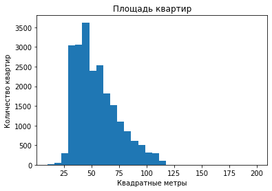

```python
plt.hist(data['total_area'], bins=30, range=(10,200))
plt.title('Площадь квартир')
plt.xlabel('Квадратные метры')
plt.ylabel('Количество квартир')
plt.show()
```

Основная масса данных лежит в диапазоне до 100 кв.м. Чаще всего встречается 40-50 кв.м.

##### Жилая площадь

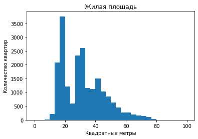

```python
plt.hist(data['living_area'], bins=30, range=(0,100))
plt.title('Жилая площадь')
plt.xlabel('Квадратные метры')
plt.ylabel('Количество квартир')
plt.show()
```

Основная масса данных лежит в диапазоне от 10 до 80 кв.м. Три пика обсуловлены, вероятно тем, что это данные для однокомнатной, 2-конатной и 3-контаных квартир соответственно.

##### Площадь кухни

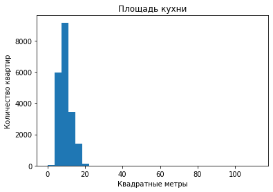

```python
plt.hist(data['kitchen_area'], bins=30, range=(0,112))
plt.title('Площадь кухни')
plt.xlabel('Квадратные метры')
plt.ylabel('Количество квартир')
plt.show()
```

Основная масса данных лежит в диапазоне от 0 до 20 кв.м. Чаще всего встречаются кухни в районе 10 кв.м.

##### Цена объекта

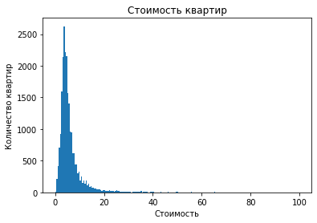

```python
data['last_price'] = data['last_price']/1000000 # Для удобства переведу цену за квартиру в млн.руб
plt.hist(data['last_price'], bins=200, range=(0,100))
plt.title('Стоимость квартир')
plt.xlabel('Стоимость')
plt.ylabel('Количество квартир')
plt.show()
```

##### Количество комнат

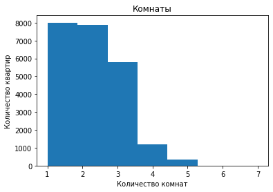

```python
plt.hist(data['rooms'], bins=7, range=(1,7))
plt.title('Комнаты')
plt.xlabel('Количество комнат')
plt.ylabel('Количество квартир')
plt.show()
```

Чаще всего встречаются однокомнатные и двухкомнатные квартиры. Значительно меньше 4-конатных вариантов, а объекты с 5 комнатами и больше встречаются редко.

##### Высота потолков

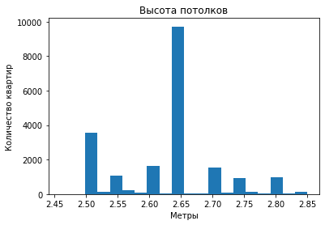

```python
plt.hist(data.query('(ceiling_height > 2) & (ceiling_height < 4)')['ceiling_height'], bins=20)
plt.title('Высота потолков')
plt.xlabel('Метры')
plt.ylabel('Количество квартир')
plt.show()
```

Высота потолков основной массы объектов укладывается в диапазон от 2,5 до 3 метров. Более 3 метров - редкие случаи. Чаще всего встречается 2,6-2,75 м.

##### Этаж квартиры

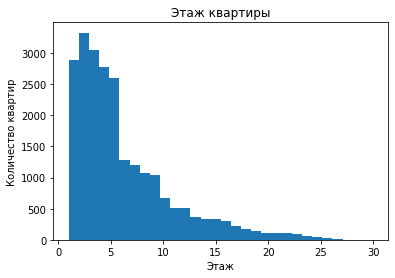

```python
plt.hist(data['floor'], bins=30, range=(1,30))
plt.title('Этаж квартиры')
plt.xlabel('Этаж')
plt.ylabel('Количество квартир')
plt.show()
```

Основная масса данных лежит в диапазоне от 1 до 20 этажа. Объекты быши 25 этажа встречаются редко. Чаще всего встречается 2 и 3 этажи.

##### Тип этажа квартиры

```python
#Добавим столбец, в котором каждому типу этажа будет присвоено цифровое значение: Первый этаж =1, Послений=2, Другой=0.
def translate_in_number(row):
    floor_status= row['floor_status']

    if floor_status == 'другой':
        return 0

    if floor_status == 'первый':
        return 1

    if floor_status == 'последний':
        return 2

data['floor_status_number'] = data.apply(translate_in_number, axis = 1)
data.head(10)#Проверим себя
```

|  | total_images | last_price | total_area | first_day_exposition | rooms | ceiling_height | floors_total | living_area | floor | is_apartment | studio | open_plan | kitchen_area | balcony | locality_name | airports_nearest | cityCenters_nearest | parks_around3000 | parks_nearest | ponds_around3000 | ponds_nearest | days_exposition | price_per_meter | day_of_week_exposition | day_of_week_exposition_number | month_exposition | year_exposition | floor_status | city_center_distance_km | … |
| --- | --- | --- | --- | --- | --- | --- | --- | --- | --- | --- | --- | --- | --- | --- | --- | --- | --- | --- | --- | --- | --- | --- | --- | --- | --- | --- | --- | --- | --- | --- |
| 0 | 20 | 13.000 | 108.00 | 2019-03-07 | 3 | 2.70 | 16.0 | 51.00 | 8 | False | False | False | NaN | 0.0 | Санкт-Петербург | 18863.0 | 16028.0 | 1.0 | 482.0 | 2.0 | 755.0 | NaN | 120370.37 | Thursday | 3 | March | 2019 | другой | 16.028 | … |
| 1 | 7 | 3.350 | 40.40 | 2018-12-04 | 1 | 2.65 | 11.0 | 18.60 | 1 | False | False | False | 11.00 | 2.0 | поселок Шушары | 12817.0 | 18603.0 | 0.0 | NaN | 0.0 | NaN | 81.0 | 82920.79 | Tuesday | 1 | December | 2018 | первый | 18.603 | … |
| 2 | 10 | 5.196 | 56.00 | 2015-08-20 | 2 | 2.65 | 5.0 | 34.30 | 4 | False | False | False | 8.30 | 0.0 | Санкт-Петербург | 21741.0 | 13933.0 | 1.0 | 90.0 | 2.0 | 574.0 | NaN | 92785.71 | Thursday | 3 | August | 2015 | другой | 13.933 | … |
| 3 | 0 | 64.900 | NaN | 2015-07-24 | 3 | 2.65 | 14.0 | NaN | 9 | False | False | False | NaN | 0.0 | Санкт-Петербург | 28098.0 | 6800.0 | 2.0 | 84.0 | 3.0 | 234.0 | 424.0 | NaN | Friday | 4 | July | 2015 | другой | 6.800 | … |
| 4 | 2 | 10.000 | 100.00 | 2018-06-19 | 2 | NaN | 14.0 | 32.00 | 13 | False | False | False | NaN | 0.0 | Санкт-Петербург | 31856.0 | 8098.0 | 2.0 | 112.0 | 1.0 | 48.0 | 121.0 | 100000.00 | Tuesday | 1 | June | 2018 | другой | 8.098 | … |
| 5 | 10 | 2.890 | 30.40 | 2018-09-10 | 1 | 2.65 | 12.0 | 14.40 | 5 | False | False | False | 9.10 | 0.0 | городской поселок Янино-1 | NaN | NaN | 0 | NaN | 0 | NaN | 55.0 | 95065.79 | Monday | 0 | September | 2018 | другой | NaN | … |
| 6 | 6 | 3.700 | 37.30 | 2017-11-02 | 1 | 2.65 | 26.0 | 10.60 | 6 | False | False | False | 14.40 | 1.0 | поселок Парголово | 52996.0 | 19143.0 | 0.0 | NaN | 0.0 | NaN | 155.0 | 99195.71 | Thursday | 3 | November | 2017 | другой | 19.143 | … |
| 7 | 5 | 7.915 | 71.60 | 2019-04-18 | 2 | 2.65 | 24.0 | NaN | 22 | False | False | False | 18.90 | 2.0 | Санкт-Петербург | 23982.0 | 11634.0 | 0.0 | NaN | 0.0 | NaN | NaN | 110544.69 | Thursday | 3 | April | 2019 | другой | 11.634 | … |
| 8 | 20 | 2.900 | 33.16 | 2018-05-23 | 1 | 2.65 | 27.0 | 15.43 | 26 | False | False | False | 8.81 | 0.0 | поселок Мурино | NaN | NaN | 0 | NaN | 0 | NaN | 189.0 | 87454.76 | Wednesday | 2 | May | 2018 | другой | NaN | … |
| 9 | 18 | 5.400 | 61.00 | 2017-02-26 | 3 | 2.50 | 9.0 | 43.60 | 7 | False | False | False | 6.50 | 2.0 | Санкт-Петербург | 50898.0 | 15008.0 | 0.0 | NaN | 0.0 | NaN | 289.0 | 88524.59 | Sunday | 6 | February | 2017 | другой | 15.008 | … |

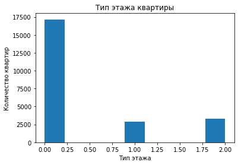

```python
plt.hist(data['floor_status_number'], bins=9, range=(0,2))
plt.title('Тип этажа квартиры')
plt.xlabel('Тип этажа')
plt.ylabel('Количество квартир')
plt.show()
```

Больше всего объектов расположены не на первом и не на последнем этажах. Если сравнивать первый и последний, то объектов, расположенных на последнем этаже больше.

##### Общее количество этажей в доме

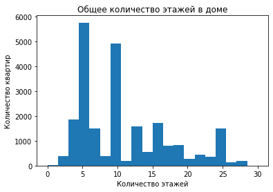

```python
plt.hist(data['floors_total'], bins=20, range=(0,30))
plt.title('Общее количество этажей в доме')
plt.xlabel('Количество этажей')
plt.ylabel('Количество квартир')
plt.show()
```

Выделяется два пика в 5 жтажей и в 8-10 этажей. Домов с этажностью больше 25 значительно меньше.

##### Расстояние до центра города в метрах

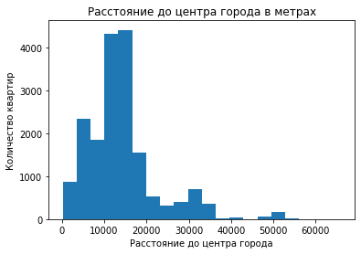

```python
plt.hist(data['cityCenters_nearest'], bins=20)
plt.title('Расстояние до центра города в метрах')
plt.xlabel('Расстояние до центра города')
plt.ylabel('Количество квартир')
plt.show()
```

Основная масса данных лежит в диапазоне от 0 до 36000 м. Чаще всего объекты распологаются на расстоянии от 10000-17000 м.

##### Расстояние до ближайшего аэропорта

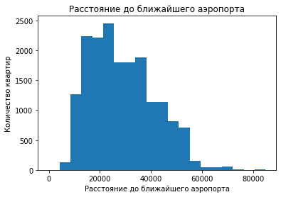

```python
plt.hist(data['airports_nearest'], bins=20)
plt.title('Расстояние до ближайшего аэропорта')
plt.xlabel('Расстояние до ближайшего аэропорта')
plt.ylabel('Количество квартир')
plt.show()
```

##### Расстояние до ближайшего парка

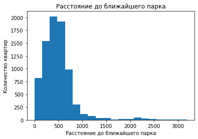

```python
plt.hist(data['parks_nearest'], bins=20)
plt.title('Расстояние до ближайшего парка')
plt.xlabel('Расстояние до ближайшего парка')
plt.ylabel('Количество квартир')
plt.show()
```

Основная масса данных лежит в диапазоне от 0 до 1000 м. Чаще всего объекты распологаются на расстоянии до парка, примерно, 450-500 м.

##### День и Месяц публикации объявления

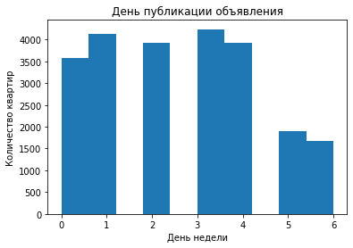

```python
plt.hist(data['day_of_week_exposition_number'])
plt.title('День публикации объявления')
plt.xlabel('День недели')
plt.ylabel('Количество квартир')
plt.show()
```

Больше всего размещали объявлние в четверг, меньше в воскресенье.

```python
#Для того чтобы построить гистограмму по месяцам, в исходный датафрейм добавим столбец, в котором каждому месяцу будет
#соответствовать цивровое значение. Например, январь=0, февраль=1 ...декабрь=11.
def translate_in_number_month(row):
    month_exposition= row['month_exposition']

    if month_exposition == 'January':
        return 0

    if month_exposition == 'February':
        return 1

    if month_exposition == 'March':
        return 2

    if month_exposition == 'April':
        return 3

    if month_exposition == 'May':
        return 4

    if month_exposition == 'June':
        return 5

    if month_exposition == 'July':
        return 6

    if month_exposition == 'August':
        return 7

    if month_exposition == 'September':
        return 8

    if month_exposition == 'October':
        return 9

    if month_exposition == 'November':
        return 10

    if month_exposition == 'December':
        return 11

data['month_exposition_number'] = data.apply(translate_in_number_month, axis = 1)
data.head(10)#Проверим себя
```

|  | total_images | last_price | total_area | first_day_exposition | rooms | ceiling_height | floors_total | living_area | floor | is_apartment | studio | open_plan | kitchen_area | balcony | locality_name | airports_nearest | cityCenters_nearest | parks_around3000 | parks_nearest | ponds_around3000 | ponds_nearest | days_exposition | price_per_meter | day_of_week_exposition | day_of_week_exposition_number | month_exposition | year_exposition | floor_status | city_center_distance_km | … |
| --- | --- | --- | --- | --- | --- | --- | --- | --- | --- | --- | --- | --- | --- | --- | --- | --- | --- | --- | --- | --- | --- | --- | --- | --- | --- | --- | --- | --- | --- | --- |
| 0 | 20 | 13.000 | 108.00 | 2019-03-07 | 3 | 2.70 | 16.0 | 51.00 | 8 | False | False | False | NaN | 0.0 | Санкт-Петербург | 18863.0 | 16028.0 | 1.0 | 482.0 | 2.0 | 755.0 | NaN | 120370.37 | Thursday | 3 | March | 2019 | другой | 16.028 | … |
| 1 | 7 | 3.350 | 40.40 | 2018-12-04 | 1 | 2.65 | 11.0 | 18.60 | 1 | False | False | False | 11.00 | 2.0 | поселок Шушары | 12817.0 | 18603.0 | 0.0 | NaN | 0.0 | NaN | 81.0 | 82920.79 | Tuesday | 1 | December | 2018 | первый | 18.603 | … |
| 2 | 10 | 5.196 | 56.00 | 2015-08-20 | 2 | 2.65 | 5.0 | 34.30 | 4 | False | False | False | 8.30 | 0.0 | Санкт-Петербург | 21741.0 | 13933.0 | 1.0 | 90.0 | 2.0 | 574.0 | NaN | 92785.71 | Thursday | 3 | August | 2015 | другой | 13.933 | … |
| 3 | 0 | 64.900 | NaN | 2015-07-24 | 3 | 2.65 | 14.0 | NaN | 9 | False | False | False | NaN | 0.0 | Санкт-Петербург | 28098.0 | 6800.0 | 2.0 | 84.0 | 3.0 | 234.0 | 424.0 | NaN | Friday | 4 | July | 2015 | другой | 6.800 | … |
| 4 | 2 | 10.000 | 100.00 | 2018-06-19 | 2 | NaN | 14.0 | 32.00 | 13 | False | False | False | NaN | 0.0 | Санкт-Петербург | 31856.0 | 8098.0 | 2.0 | 112.0 | 1.0 | 48.0 | 121.0 | 100000.00 | Tuesday | 1 | June | 2018 | другой | 8.098 | … |
| 5 | 10 | 2.890 | 30.40 | 2018-09-10 | 1 | 2.65 | 12.0 | 14.40 | 5 | False | False | False | 9.10 | 0.0 | городской поселок Янино-1 | NaN | NaN | 0 | NaN | 0 | NaN | 55.0 | 95065.79 | Monday | 0 | September | 2018 | другой | NaN | … |
| 6 | 6 | 3.700 | 37.30 | 2017-11-02 | 1 | 2.65 | 26.0 | 10.60 | 6 | False | False | False | 14.40 | 1.0 | поселок Парголово | 52996.0 | 19143.0 | 0.0 | NaN | 0.0 | NaN | 155.0 | 99195.71 | Thursday | 3 | November | 2017 | другой | 19.143 | … |
| 7 | 5 | 7.915 | 71.60 | 2019-04-18 | 2 | 2.65 | 24.0 | NaN | 22 | False | False | False | 18.90 | 2.0 | Санкт-Петербург | 23982.0 | 11634.0 | 0.0 | NaN | 0.0 | NaN | NaN | 110544.69 | Thursday | 3 | April | 2019 | другой | 11.634 | … |
| 8 | 20 | 2.900 | 33.16 | 2018-05-23 | 1 | 2.65 | 27.0 | 15.43 | 26 | False | False | False | 8.81 | 0.0 | поселок Мурино | NaN | NaN | 0 | NaN | 0 | NaN | 189.0 | 87454.76 | Wednesday | 2 | May | 2018 | другой | NaN | … |
| 9 | 18 | 5.400 | 61.00 | 2017-02-26 | 3 | 2.50 | 9.0 | 43.60 | 7 | False | False | False | 6.50 | 2.0 | Санкт-Петербург | 50898.0 | 15008.0 | 0.0 | NaN | 0.0 | NaN | 289.0 | 88524.59 | Sunday | 6 | February | 2017 | другой | 15.008 | … |

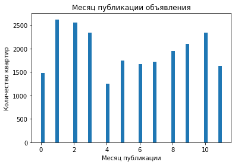

```python
plt.hist(data['month_exposition_number'], bins=50, range=(0,11))
plt.title('Месяц публикации объявления')
plt.xlabel('Месяц публикации')
plt.ylabel('Количество квартир')
plt.show()
```

Больше всего публикаций было в феврале, меньше всего в мае.

#### Изучение времени продажи квартиры

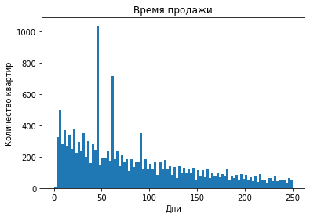

```
count    18562.000000
mean       129.034264
std        121.640084
min          1.000000
25%         42.000000
50%         85.000000
75%        183.000000
max        512.000000
Name: days_exposition, dtype: float64
```

```python
# Гистограма времени продажи
plt.hist(data['days_exposition'], bins=100, range=(0,250))
plt.title('Время продажи')
plt.xlabel('Дни')
plt.ylabel('Количество квартир')
plt.show()
# Изучаем значения срока продажи
data.query('days_exposition != 9999')['days_exposition'].describe()
```

#### Изучение влияния факторов на общую (полную) стоимость объекта?

##### Зависимость от общей площади

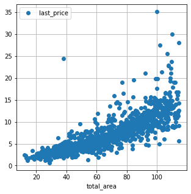

```
Корреляция цены и площади:

            last_price  total_area
last_price     1.00000     0.47191
total_area     0.47191     1.00000
```

```python
(
    data.pivot_table(index='total_area', values='last_price')
    .plot(grid=True, style='o', figsize=(5, 5))
)
plt.show()
print('Корреляция цены и площади:','\n')
print(data.pivot_table(index='floor', values=['total_area', 'last_price']).corr(),'\n')
```

Выраженная зависимость цены от общей площади: чем больше площадь, тем выше цена.

##### Зависимость от жилой площади

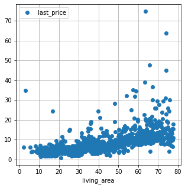

```
Корреляция цены и площади:

             last_price  living_area
last_price     1.000000     0.437062
living_area    0.437062     1.000000
```

```python
(
    data.pivot_table(index='living_area', values='last_price')
    .plot(grid=True, style='o', figsize=(5, 5))
)
plt.show()
print('Корреляция цены и площади:','\n')
print(data.pivot_table(index='floor', values=['living_area', 'last_price']).corr(),'\n')
```

Выраженная зависимость цены от жилой площади: чем больше площадь, тем выше цена.

##### Зависимость от площади кухни

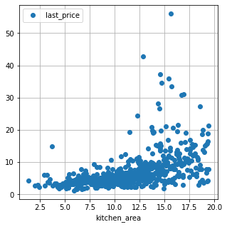

```
Корреляция цены и площади:

              kitchen_area  last_price
kitchen_area      1.000000    0.109654
last_price        0.109654    1.000000
```

```python
(
    data.pivot_table(index='kitchen_area', values='last_price')
    .plot(grid=True, style='o', figsize=(5, 5))
)
plt.show()
print('Корреляция цены и площади:','\n')
print(data.pivot_table(index='floor', values=['kitchen_area', 'last_price']).corr(),'\n')
```

Зависимость цены от площади кухни слабая. Утверждать о том, что с увелечением площади кухни увеличчивается цена - нельзя.

##### Зависимость от количества комнат

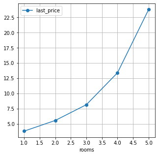

```
Корреляция цены и числа комнат:

            last_price     rooms
last_price    1.000000  0.613961
rooms         0.613961  1.000000
```

```python
(
    data.query('rooms > 0').pivot_table(index='rooms', values='last_price')
    .plot(grid=True, style='o-', figsize=(5, 5))
)
plt.show()
print('Корреляция цены и числа комнат:','\n')
print(data.query('rooms > 0').pivot_table(index='floor', values=['rooms', 'last_price']).corr(),'\n')
```

Зависимость есть: с увеличением числа комнат увеличивается и цена.

##### Зависимость от этажа, на котором находится квартира

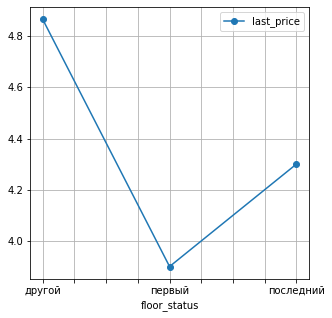

```python
(
    data.pivot_table(index='floor_status', values='last_price', aggfunc='median')
    .plot(grid=True, style='o-', figsize=(5, 5))
)
plt.show()
```

Цена квартиры падает, если объект находится на первом этаже. Ситуация с последним этажом чуть лучше, но все равно цена ниже, чем у квартир на других этажах.

##### Зависимость от даты размещения

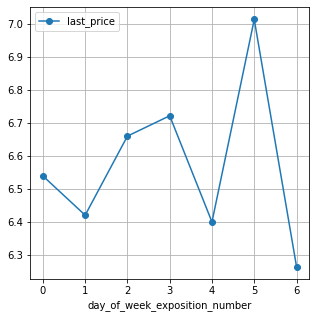

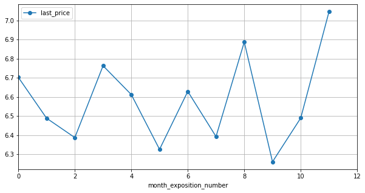

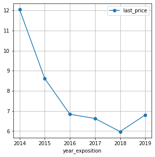

```python
# Зависимость от дня размещения
(
    data.pivot_table(index='day_of_week_exposition_number', values='last_price')
    .plot(grid=True, style='o-', figsize=(5, 5))
)
plt.show()
# Зависимость от месяца размещения
(
    data.pivot_table(index='month_exposition_number', values='last_price')
    .plot(grid=True, style='o-', xlim=(0,12), figsize=(10, 5))
)
plt.show()
# Зависимость от года размещения
(
    data.pivot_table(index='year_exposition', values='last_price')
    .plot(grid=True, style='o-', figsize=(5, 5))
)
plt.show()
```

#### Посчитать среднюю цену одного квадратного метра в 10 населённых пунктах

```python
# Сравниваем среднюю стоимость квадратного метра в топ-10 городов по числу объявлений
city_ten = data['locality_name'].value_counts().head(10)
city_sm_price = data.query('locality_name in (@city_ten.index)').pivot_table(values='price_per_meter', index='locality_name')
city_sm_price = city_sm_price.astype(int)
city_sm_price.sort_values('price_per_meter', ascending=False)
```

| locality_name | price_per_meter |
| --- | --- |
| Санкт-Петербург | 110661 |
| Пушкин | 101960 |
| деревня Кудрово | 92229 |
| поселок Парголово | 90448 |
| поселок Мурино | 85029 |
| поселок Шушары | 78303 |
| Колпино | 75370 |
| Гатчина | 68919 |
| Всеволожск | 68637 |
| Выборг | 58225 |

**Вывод:** Наибольшая стоимость квадратного метра, как и ожидалось, в Санкт-Петербурге. Наименьшая - Выборг, что объясняется его небольшой численностью населения и большой удаленностью от Санкт-Петербурга. Учитвая, что также нельшая цена за кв.м. наблюдается в городах Гатчина и Всеволожск (тоже далеко находятся от Питера) можно сделать вывод о том, что цена за кв.м. уменьшается с увеличение отдаленности от Санкт-Петербурга. Проверим это в следующем пункте.

#### Вычислить среднюю цену каждого километра

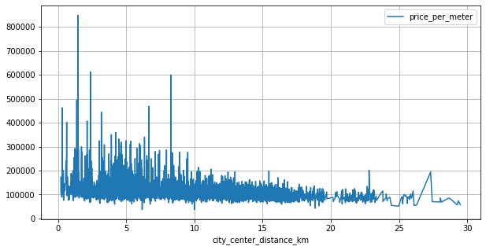

```python
depend_price_km = data.query('locality_name == "Санкт-Петербург"').pivot_table(index='city_center_distance_km', values='price_per_meter', aggfunc='mean')
depend_price_km.head(10)
depend_price_km.plot(figsize=(10, 5), grid=True)
```

Чем дальше объект находится от центра, тем дешевле его кв.м.

### Общий вывод

**Цель:**найти интересные особенности и зависимости, которые существуют на рынке недвижимости. **Что было сделано:**  
1)Прочитали файл и сохранили его в data. Предварительно ознакомились с данными.  
2)Произвели предобработку данных:

- Заполнили пропуски в данных;
- Изменили типы данных;
- Изабивились от неявных дубликатов;
- Изабивились от выбивающихся значений;
- Добавлены столбцы, необходимые для дальнейшего анализа.

В большей степени (коэфф. корр. 0,6139) цена за квартиру зависит от количество комнат: чем больше комнат, тем выше цена. В меньшей степени цена на квартиру зависит от общей площади (коэфф. корр. 0,4719).